# Week 10: Querying the History database of Chrome

Author: Eni Mustafaraj  
Date: Nov 5, 2017

**OVERVIEW:** Today we will perform two steps in the data science cycle, getting data and exploring data. These are iterative steps, as we know. We might need to be in this loop for a while, until we get to know better what questions we can answer with this data.

**Table of Contents**

1. Accessing the History page
2. The `sqlite3` module
3. Explore the tables in the database
4. Explore visits
5. Find most visited websites
6. Connecting with pandas
7. Tasks for you

**More information**

We're disussing the Chrome history file in this notebook. If you want to see screenshots of what the tables in the database look like, you can [visit this page](http://kb.digital-detective.net/display/BF/History).

Additionally, it is possible to download an app that has a GUI interface to inspect the database.  
This browser is recommended by our TA Clara: [SQLite browser](http://sqlitebrowser.org/).

## 1. Accessing the History page

The Chrome browser keeps track of interactions you perform on the Chrome browser:

- searches you perform on the "location" bar
- links you open either directly or by clicking on links on a page

All this information is stored in a file named 'History'. In the Mac computer, you can access  
this file by going to this local URL (**after replacing USERNAME with your own**):

file:///Users/USERNAME/Library/Application%20Support/Google/Chrome/Default/

On Windows, you should be able to do the same with the path:

C:\Users\USERNAME\AppData\Local\Google\Chrome\User Data\Default

If you download this file from this page in the browser, you can **move it** to the folder  
that contains this notebook as well. Alternatively, once you make sure that it exists  
and contains enough content, you can use the path to it instead.

If you open the file, at the very top you'll notice: **SQLite format 3**. That tells us that  
this file is a database file that we can access in Python via the sqlite3 module.

## 2. The `sqlite3` module

The most common way to store data is as tables in databases. There are many database systems out there, with the most used ones being **relational database management systems**, which make use of SQL (structured query language). However, NoSQL databases systems like MongoDB or Redis are also very popular.

SQLite is a database management system that doesn't require a server, which makes it different from more traditional systems like MySQL or Oracle.

To learn more about SQLite, I recommend [their tutorial](http://www.sqlitetutorial.net/). Since we will not be creating our own databases in this class, we don't need to learn much about it. However, taking the CS 304 Databases course at some point is a good investment.

We will use Python's interface `sqlite3` to talk to an SQLite file in order to read the content of it and submit different queries.

There is a [very short (one page) tutorial](http://www.sqlitetutorial.net/sqlite-python/sqlite-python-select/) in their website that shows how to talk to SQLite only to query data.

```python
import sqlite3
```

To talk to a database, we need to establish a connection to it. It's a bit similar to opening files, we have to provide the path to the database.

```python
 path = r"C:\Users\vikiz\Desktop\Week10-ChromeHistory\History" # if you stored the file in the folder

# alternatively, we can use the path to the real History file (not a copy of it)
# remember to change the USERNAME
#path = "C:\Users\vikiz\Desktop\Week10-ChromeHistory"
```

```python
conn = sqlite3.connect(path)
conn
```

```
<sqlite3.Connection at 0x907fbf8>
```

To talk to the database now that we have a connection, we need to create a "cursor" object.  
Through the cursor we will execute queries in the database, for example, find the tables  
of a database:

```python
cursor = conn.cursor()
cursor
# cursor.execute("SELECT name FROM sqlite_master WHERE type='table';")
# for data in cursor.fetchall():
#     print data
```

```
<sqlite3.Cursor at 0x95570a0>
```

```python
# This means: select everything from the table urls
cursor = conn.execute('select * from urls')

# This asks to show a description of the columns of the table
cursor.description
```

```
(('id', None, None, None, None, None, None),
 ('url', None, None, None, None, None, None),
 ('title', None, None, None, None, None, None),
 ('visit_count', None, None, None, None, None, None),
 ('typed_count', None, None, None, None, None, None),
 ('last_visit_time', None, None, None, None, None, None),
 ('hidden', None, None, None, None, None, None))
```

It seems that the only useful information is the name of the columns, so we'll focus on them:

```python
colnames = [description[0] for description in cursor.description]
colnames
```

```
['id',
 'url',
 'title',
 'visit_count',
 'typed_count',
 'last_visit_time',
 'hidden']
```

The purpose of knowing the column names is to use them in queries. For example, the query below asks to extract the values of only three columns:

```python
cursor = conn.execute('select url, title, visit_count from urls')
rows = cursor.fetchall()
for i in range(10):
    print rows[i]
```

```
(u'https://sakai.wellesley.edu/', u'Sakai : Gateway : Welcome', 33)
(u'https://sakai.wellesley.edu/portal/login', u'Enter your username and password', 27)
(u'https://sakai.wellesley.edu/sakai-login-tool/container', u'Enter your username and password', 28)
(u'https://login.wellesley.edu/module.php/casserver/cas.php/login?service=https%3A%2F%2Fsakai.wellesley.edu%2Fsakai-login-tool%2Fcontainer', u'Sakai : My Workspace : Home', 54)
(u'https://login.wellesley.edu/module.php/core/loginuserpass.php?', u'Sakai : My Workspace : Home', 38)
(u'https://sakai.wellesley.edu/portal', u'Sakai : My Workspace : Home', 27)
(u'http://www.wellesley.edu/', u'Wellesley College', 1)
(u'https://2fa.wellesley.edu/dag/module.php/saml/sp/saml2-acs.php/duo_proxy', u'IIS Windows Server', 7)
(u'https://www.google.com/a/wellesley.edu/acs', u'Redirecting...', 6)
(u'https://mail.google.com/mail/u/0/', u'Wellesley College Mail', 14)
```

If we want the values from all columns to be displayed, we will use again * to select everything:

```python
cursor = conn.execute('select * from urls')
rows = cursor.fetchall()
for i in range(10):
    print rows[i]
```

```
(56, u'https://sakai.wellesley.edu/', u'Sakai : Gateway : Welcome', 33, 30, 13154490602799381L, 0)
(57, u'https://sakai.wellesley.edu/portal/login', u'Enter your username and password', 27, 0, 13154490604532794L, 0)
(58, u'https://sakai.wellesley.edu/sakai-login-tool/container', u'Enter your username and password', 28, 0, 13154490604532794L, 0)
(59, u'https://login.wellesley.edu/module.php/casserver/cas.php/login?service=https%3A%2F%2Fsakai.wellesley.edu%2Fsakai-login-tool%2Fcontainer', u'Sakai : My Workspace : Home', 54, 0, 13154490606395498L, 0)
(61, u'https://login.wellesley.edu/module.php/core/loginuserpass.php?', u'Sakai : My Workspace : Home', 38, 0, 13154490606395498L, 0)
(63, u'https://sakai.wellesley.edu/portal', u'Sakai : My Workspace : Home', 27, 0, 13154490606395498L, 0)
(84, u'http://www.wellesley.edu/', u'Wellesley College', 1, 0, 13151786738340771L, 0)
(156, u'https://2fa.wellesley.edu/dag/module.php/saml/sp/saml2-acs.php/duo_proxy', u'IIS Windows Server', 7, 0, 13154318377529139L, 0)
(158, u'https://www.google.com/a/wellesley.edu/acs', u'Redirecting...', 6, 0, 13154318378013826L, 0)
(165, u'https://mail.google.com/mail/u/0/', u'Wellesley College Mail', 14, 0, 13154318380472624L, 0)
```

There is more data here, not obvious what all of it is, but a useful value is the timestamp of the visit.  
Let's move on to another section.

## 3. Exploring the tables in the database

```python
cursor = conn.execute('select * from keyword_search_terms')
rows = cursor.fetchall()
for i in range(6):
    print rows[i]
```

```
(2, 8982, u'what does .aae mean', u'what does .AAE mean')
(2, 8983, u'wellesley college course browser', u'wellesley college course browser')
(2, 8988, u'computer science major wellesley college', u'computer science major wellesley college')
(20, 8989, u'wellesley college class of 2021', u'wellesley college class of 2021')
(2, 8995, u'wellesley college distribution requirements', u'wellesley college distribution requirements')
(2, 8999, u'wellesley college portal', u'wellesley college portal')
```

I can see the search term, but I don't understand the numbers, let's look at the meaning of the columns:

```python
cursor.description
```

```
(('keyword_id', None, None, None, None, None, None),
 ('url_id', None, None, None, None, None, None),
 ('lower_term', None, None, None, None, None, None),
 ('term', None, None, None, None, None, None))
```

I'm wondering what the `keyword_id` is, I'll go and grab all of them:

```python
# only select the column keyword_id
cursor = conn.execute('select keyword_id from keyword_search_terms')

keywordIDs = [row[0] for row in cursor.fetchall()]
print len(keywordIDs)
print keywordIDs[:10]
```

```
749
[2, 2, 2, 20, 2, 2, 2, 2, 2, 2]
```

The IDs seem to repeat, so, let's try to group them together in a counter:

```python
from collections import Counter
keywordCounter = Counter(keywordIDs)
print len(keywordCounter)
keywordCounter.most_common(5)
```

```
9
```

```
[(2, 676), (20, 40), (65, 21), (64, 7), (67, 1)]
```

Let's look at some concrete examples.

**ATTENTION:** Make sure to pick a value that shows in your data, maybe you don't have an id 10, like the example below.

```python
cursor = conn.execute('select * from keyword_search_terms where keyword_id = 30')
cursor.fetchall()[:5]
```

```
[(30,
  9492,
  u'permutations and combinations',
  u'permutations and combinations')]
```

```python
cursor = conn.execute('select * from urls where id=104640')
cursor.fetchall()
```

```
[]
```

```python
for keyID in sorted(keywordCounter):
    cursor = conn.execute('select url_id from keyword_search_terms where keyword_id = ?', (keyID,))
    urlID = cursor.fetchall()[0] # get the URL id
    # print urlID (it's a tuple, exactly what needed for the query below)
    cursor = conn.execute('select * from urls where id = ?', urlID)
    print "id={}, count={},".format(keyID, keywordCounter[keyID]),
    url = cursor.fetchall()[0][1]
    print url
```

```
id=2, count=676, https://www.google.com/search?q=+1+%2B+2+%2B+3+...+%2B+n+%3D+C%28n%2B1%2C2%29&oq=+1+%2B+2+%2B+3+...+%2B+n+%3D+C%28n%2B1%2C2%29&gs_l=psy-ab.3..0i8i30k1.6965.6965.0.8829.1.1.0.0.0.0.160.160.0j1.1.0....0...1.1.64.psy-ab..0.1.158....0.rrTsCOrKM5U
id=14, count=1, https://www.wolframalpha.com/input/?i=(k%2B1)!
id=17, count=1, https://www.google.com/maps/search/lydia/@39.1746423,25.6632697,9z
id=20, count=40, https://www.facebook.com/search/top/?q=abena%20asare
id=30, count=1, https://www.youtube.com/results?search_query=permutations+and+combinations
id=64, count=7, https://en.wikipedia.org/w/index.php?search=Chartres%20Cathedral&title=Special%3ASearch
id=65, count=21, https://www.etsy.com/search?q=black%20initials%20iphone%206s%20plus%20case
id=67, count=1, https://scholar.google.com/scholar?hl=en&as_sdt=0%2C22&q=wikipedia+vandalism&oq=wikipedia+vand
id=68, count=1, http://www.ratemyprofessors.com/search.jsp?query=kathleen+brogan
```

## 4. Explore visits

One promising table in the database is the one named 'visits', let's look more into it:

```python
cursor = conn.execute('select * from visits')
cursor.description
```

```
(('id', None, None, None, None, None, None),
 ('url', None, None, None, None, None, None),
 ('visit_time', None, None, None, None, None, None),
 ('from_visit', None, None, None, None, None, None),
 ('transition', None, None, None, None, None, None),
 ('segment_id', None, None, None, None, None, None),
 ('visit_duration', None, None, None, None, None, None))
```

Let's check what a row looks like, by looking at a few of them:

```python
cursor.fetchall()[:5]
```

```
[(22495, 598, 13146889525207104L, 0, 268435460, 0, 0),
 (22496, 8981, 13146889525207104L, 22495, -1610612732, 0, 0),
 (22497, 8982, 13146890729354454L, 0, 838860805, 0, 1614950115448L),
 (22498, 8983, 13148504871720438L, 0, 838860805, 0, 0),
 (22499, 2318, 13148504876569627L, 0, 805306368, 0, 83287450)]
```

While the column names sound interesting, it looks like the values are not that useful immediately, we'll need to look up the url in the urls table, and need to figure out whether some of the fields have values different from 0.

```python
cursor = conn.execute('select * from visits where from_visit != 0')
cursor.fetchall()[:5]
```

```
[(22496, 8981, 13146889525207104L, 22495, -1610612732, 0, 0),
 (22501, 2513, 13148504922283896L, 22500, 805306375, 39, 0),
 (22502, 8984, 13148504922467634L, 22501, 1610612736, 0, 2195823),
 (22503, 262, 13148504924663457L, 22502, 805306368, 39, 2138932),
 (22504, 3930, 13148504926802389L, 22503, 805306368, 39, 2731894)]
```

There are a few interesting observations to make here:

1. The segment_id seems like the value that links together several consequtive visits.
2. Apparently Chrome calculates the visit duration, that's good to have. Though the numbers are in microseconds.
3. The visit_time is also in a strange format: number of microseconds since January, 1601. [See this SO stack](https://stackoverflow.com/questions/2193820/convert-chrome-history-date-time-stamp-to-readable-format).

Let's look at some segments:

**ATTENTION:** Choose a segment_id that appears in your data, the value 191 might not be in yours.

```python
cursor = conn.execute('select * from visits where segment_id == 191')
cursor.fetchall()[:10]
```

```
[]
```

To make sense of these data, let's do two things:

- create meaningful timestamps
- connect to the URLs

### Figuring out the time stamps

This SO thread explains how to convert Chrome timestamps into datetime:

```python
import datetime

def convertChromeTime(ms):
    """Convert the amount of microsends into a datetime object.
    Google chrome doesn't use Unix epoch.
    """
    return datetime.datetime(1601, 1, 1) + datetime.timedelta(microseconds=ms)
```

Let's test the function:

```python
str(convertChromeTime(13146779317202318))
```

```
'2017-08-09 19:08:37.202318'
```

Let's print now both the datetime and the URL of each visit:

**ATTENTION:** You might need another id instead of 191.

```python
cursor = conn.execute('select * from visits where segment_id == 191')
for row in cursor.fetchall()[:10]:
    date = convertChromeTime(row[2]) # index of date
    url = conn.execute('select url from urls where id = ?', (row[1],)).fetchall()[0]
    print str(date)[:19], url
```

Here are my results:

```
2017-08-09 19:08:37 (u'https://scholar.google.com/',)
2017-08-09 19:08:41 (u'https://scholar.google.com/scholar?hl=en&q=sara+fulmer&btnG=&as_sdt=1%2C22&as_sdtp=',)
2017-08-09 19:08:45 (u'http://link.springer.com/article/10.1007/s10648-009-9107-x',)
2017-08-09 19:08:48 (u'https://scholar.google.com/scholar?hl=en&q=sara+fulmer&btnG=&as_sdt=1%2C22&as_sdtp=',)
2017-08-09 19:08:53 (u'https://scholar.googleusercontent.com/scholar.bib?q=info:PvUNd7wmIccJ:scholar.google.com/&output=citation&scisig=AAGBfm0AAAAAWYtgPFBBLwUeHlGKTkGFyHHQ4qxjV2XS&scisf=4&ct=citation&cd=-1&hl=en',)
2017-08-09 19:10:11 (u'https://scholar.google.com/scholar?hl=en&q=sara+fulmer&btnG=&as_sdt=1%2C22&as_sdtp=',)
2017-08-09 19:10:15 (u'https://scholar.google.com/citations?user=eoN2J7EAAAAJ&hl=en&oi=ao',)
2017-08-13 17:20:59 (u'https://scholar.google.com/',)
2017-08-13 17:21:02 (u'https://scholar.google.com/citations?user=QTP6jogAAAAJ&hl=en',)
2017-09-01 22:18:23 (u'https://scholar.google.com/',)
```

It shows a meaningful session on Google Scholar, but it has other days too, thus, the segment_id alone is not always meaningful, we'll need to investigate more.

## 5. Find most visited website

In the beginning of the notebook we saw that the table url contains counts for visits on particular URLs:

```python
cursor = conn.execute('select url, title, visit_count from urls')
cursor.fetchall()[:10]
```

```
[(u'https://sakai.wellesley.edu/', u'Sakai : Gateway : Welcome', 33),
 (u'https://sakai.wellesley.edu/portal/login',
  u'Enter your username and password',
  27),
 (u'https://sakai.wellesley.edu/sakai-login-tool/container',
  u'Enter your username and password',
  28),
 (u'https://login.wellesley.edu/module.php/casserver/cas.php/login?service=https%3A%2F%2Fsakai.wellesley.edu%2Fsakai-login-tool%2Fcontainer',
  u'Sakai : My Workspace : Home',
  54),
 (u'https://login.wellesley.edu/module.php/core/loginuserpass.php?',
  u'Sakai : My Workspace : Home',
  38),
 (u'https://sakai.wellesley.edu/portal', u'Sakai : My Workspace : Home', 27),
 (u'http://www.wellesley.edu/', u'Wellesley College', 1),
 (u'https://2fa.wellesley.edu/dag/module.php/saml/sp/saml2-acs.php/duo_proxy',
  u'IIS Windows Server',
  7),
 (u'https://www.google.com/a/wellesley.edu/acs', u'Redirecting...', 6),
 (u'https://mail.google.com/mail/u/0/', u'Wellesley College Mail', 14)]
```

But this data contains a lot of repetitions, because it's looking at unique URLs, instead of domain names. Thus, it makes sense to only look for domain names.

### Extracting domain names from URLs

We don't need to do anything special, we simply use one of Python's libraries for parsing URLs:

```python
from urllib2 import urlparse
```

```python
urlparse.urlparse('https://portal.wellesley.edu/frontpage?destination=frontpage')
```

```
ParseResult(scheme='https', netloc='portal.wellesley.edu', path='/frontpage', params='', query='destination=frontpage', fragment='')
```

There are multiple parts here, we are interested in "netloc":

```python
urlparse.urlparse('https://portal.wellesley.edu/frontpage?destination=frontpage').netloc
```

```
'portal.wellesley.edu'
```

### Counting domain names

The algorithm:

- get every URL and its count as it is shown in the urls table
- extract the domain name (that leaves out specific parts of the URL)
- update count of domain names

```python
from collections import Counter

domainCounter = Counter()
cursor = conn.execute('select url, visit_count from urls')

for row in cursor.fetchall():
    url, count = row # grab the exisiting count for that URL
    print url
    domain = urlparse.urlparse(url).netloc
    domainCounter[domain] += count # accumulate URL counts

domainCounter.most_common(10)
```

[output not shown]

[output cut: 4722 more lines]

[output not shown]

```
[(u'docs.google.com', 7814),
 (u'fivethirtyeight.com', 5682),
 (u'mail.google.com', 2064),
 (u'www.facebook.com', 1662),
 (u'github.com', 1425),
 (u'www.google.com', 1098),
 (u'sakai.wellesley.edu', 567),
 (u'cs.wellesley.edu', 381),
 (u'drive.google.com', 213),
 (u'en.wikipedia.org', 162)]
```

My results look like this:

```
[(u'docs.google.com', 45585),
 (u'mail.google.com', 31301),
 (u'fivethirtyeight.com', 2382),
 (u'www.google.com', 2263),
 (u'drive.google.com', 1680),
 (u'cs.wellesley.edu', 1353),
 (u'en.wikipedia.org', 1277),
 (u'gradescope.com', 1250),
 (u'calendar.google.com', 1198),
 (u'cs111.wellesley.edu', 1114)]
```

They clearly indicate how much my work relies on Google docs and email and that I work at Wellesley CS,  
I grade a lot on Gradescope, and I teach (or I'm taking) CS 111 ;)

What does your top 10 look like?

## 6. Connecting with pandas

It turns out, the almighty `pandas` can talk the `sqlite3` and convert tables into dataframes.

```python
import pandas as pd
```

```python
# notice the second argument, the variable that stores the connection
df = pd.read_sql_query("select * from urls", conn)
df.head()
```

|  | id | url | title | visit_count | typed_count | last_visit_time | hidden |
| --- | --- | --- | --- | --- | --- | --- | --- |
| 0 | 56 | https://sakai.wellesley.edu/ | Sakai : Gateway : Welcome | 33 | 30 | 13154490602799381 | 0 |
| 1 | 57 | https://sakai.wellesley.edu/portal/login | Enter your username and password | 27 | 0 | 13154490604532794 | 0 |
| 2 | 58 | https://sakai.wellesley.edu/sakai-login-tool/c... | Enter your username and password | 28 | 0 | 13154490604532794 | 0 |
| 3 | 59 | https://login.wellesley.edu/module.php/casserv... | Sakai : My Workspace : Home | 54 | 0 | 13154490606395498 | 0 |
| 4 | 61 | https://login.wellesley.edu/module.php/core/lo... | Sakai : My Workspace : Home | 38 | 0 | 13154490606395498 | 0 |

Remember vectorized operations? We can apply the helper function `convertChromeTime` to the column `last_visit_time` to get the datetime:

```python
# I'm creating a new column in the dataframe
df['datetime'] = df['last_visit_time'].apply(convertChromeTime)
```

```python
df.head()
```

|  | id | url | title | visit_count | typed_count | last_visit_time | hidden | datetime |
| --- | --- | --- | --- | --- | --- | --- | --- | --- |
| 0 | 56 | https://sakai.wellesley.edu/ | Sakai : Gateway : Welcome | 33 | 30 | 13154490602799381 | 0 | 2017-11-07 01:10:02.799381 |
| 1 | 57 | https://sakai.wellesley.edu/portal/login | Enter your username and password | 27 | 0 | 13154490604532794 | 0 | 2017-11-07 01:10:04.532794 |
| 2 | 58 | https://sakai.wellesley.edu/sakai-login-tool/c... | Enter your username and password | 28 | 0 | 13154490604532794 | 0 | 2017-11-07 01:10:04.532794 |
| 3 | 59 | https://login.wellesley.edu/module.php/casserv... | Sakai : My Workspace : Home | 54 | 0 | 13154490606395498 | 0 | 2017-11-07 01:10:06.395498 |
| 4 | 61 | https://login.wellesley.edu/module.php/core/lo... | Sakai : My Workspace : Home | 38 | 0 | 13154490606395498 | 0 | 2017-11-07 01:10:06.395498 |

Find how many URLs:

```python
df.shape
```

```
(4777, 8)
```

As we discussed, the most interesting table is `visits`, thus, let's load that into a dataframe:

```python
visitDF = pd.read_sql_query("select * from visits", conn)
visitDF.head()
```

|  | id | url | visit_time | from_visit | transition | segment_id | visit_duration |
| --- | --- | --- | --- | --- | --- | --- | --- |
| 0 | 22495 | 598 | 13146889525207104 | 0 | 268435460 | 0 | 0 |
| 1 | 22496 | 8981 | 13146889525207104 | 22495 | -1610612732 | 0 | 0 |
| 2 | 22497 | 8982 | 13146890729354454 | 0 | 838860805 | 0 | 1614950115448 |
| 3 | 22498 | 8983 | 13148504871720438 | 0 | 838860805 | 0 | 0 |
| 4 | 22499 | 2318 | 13148504876569627 | 0 | 805306368 | 0 | 83287450 |

```python
visitDF.shape
```

```
(24313, 7)
```

We can also do the same for the keyword searches:

```python
queriesDF = pd.read_sql_query("select * from keyword_search_terms", conn)
queriesDF.head()
```

|  | keyword_id | url_id | lower_term | term |
| --- | --- | --- | --- | --- |
| 0 | 2 | 8982 | what does .aae mean | what does .AAE mean |
| 1 | 2 | 8983 | wellesley college course browser | wellesley college course browser |
| 2 | 2 | 8988 | computer science major wellesley college | computer science major wellesley college |
| 3 | 20 | 8989 | wellesley college class of 2021 | wellesley college class of 2021 |
| 4 | 2 | 8995 | wellesley college distribution requirements | wellesley college distribution requirements |

```python
queriesDF.shape
```

```
(749, 4)
```

### Joining two tables

As we see in the tables above, the URL name is only in the urls table, while the two other tables contain an ID. This means that we have to look up the URL using the ID. A better way is to combine the two tables together, that is, to join them.

Joining is a topic in database theory, you can read more in this website: [SQLite inner join](http://www.sqlitetutorial.net/sqlite-inner-join/).

For our two tables visits and urls, we'll do the following

```
SELECT urls.url, visit_time, visit_duration
FROM visits
INNER JOIN urls on urls.id = visits.url
```

let's try it out:

```python
cursor = conn.execute("SELECT urls.url, visit_time, visit_duration FROM visits INNER JOIN urls on urls.id = visits.url")
cursor.fetchall()[:3]
```

```
[(u'data:text/html,chromewebdata', 13146889525207104L, 0),
 (u'https://hangouts.google.com/webchat/u/0/load?client=sm&prop=gmail&nav=true&fid=gtn-roster-iframe-id&os=Win32&stime=1502207190815&xpc=%7B%22cn%22%3A%22xqwa39%22%2C%22tp%22%3A1%2C%22ifrid%22%3A%22gtn-roster-iframe-id%22%2C%22pu%22%3A%22https%3A%2F%2Fhangouts.google.com%2Fwebchat%2Fu%2F0%2F%22%7D&e…
  13146889525207104L,
  0),
 (u'https://www.google.com/search?q=what+does+.AAE+mean&oq=what+does+.AAE+mean&aqs=chrome..69i57j0l5.4098j0j7&sourceid=chrome&ie=UTF-8',
  13146890729354454L,
  1614950115448L)]
```

Now that we know that the query works, we can create the dataframe of the join:

```python
query = "SELECT urls.url, visit_time, visit_duration FROM visits INNER JOIN urls on urls.id = visits.url"
visitAndURLs = pd.read_sql_query(query, conn)
visitAndURLs.head()
```

|  | url | visit_time | visit_duration |
| --- | --- | --- | --- |
| 0 | data:text/html,chromewebdata | 13146889525207104 | 0 |
| 1 | https://hangouts.google.com/webchat/u/0/load?c... | 13146889525207104 | 0 |
| 2 | https://www.google.com/search?q=what+does+.AAE... | 13146890729354454 | 1614950115448 |
| 3 | https://www.google.com/search?q=wellesley+coll... | 13148504871720438 | 0 |
| 4 | https://courses.wellesley.edu/ | 13148504876569627 | 83287450 |

Let's change the times and duration:

```python
df = visitAndURLs
df['visit_duration'] = df['visit_duration'].apply(lambda x: x/1000000.) # convert into seconds
df['visit_time'] = df['visit_time'].apply(convertChromeTime)
df.head()
```

|  | url | visit_time | visit_duration |
| --- | --- | --- | --- |
| 0 | data:text/html,chromewebdata | 2017-08-11 01:45:25.207104 | 0.000000e+00 |
| 1 | https://hangouts.google.com/webchat/u/0/load?c... | 2017-08-11 01:45:25.207104 | 0.000000e+00 |
| 2 | https://www.google.com/search?q=what+does+.AAE... | 2017-08-11 02:05:29.354454 | 1.614950e+06 |
| 3 | https://www.google.com/search?q=wellesley+coll... | 2017-08-29 18:27:51.720438 | 0.000000e+00 |
| 4 | https://courses.wellesley.edu/ | 2017-08-29 18:27:56.569627 | 8.328745e+01 |

```python
df.tail()
```

|  | url | visit_time | visit_duration |
| --- | --- | --- | --- |
| 24308 | https://mail.google.com/mail/u/0/#inbox/15f97e... | 2017-11-07 19:26:01.720569 | 0.0 |
| 24309 | https://mail.google.com/mail/u/0/#inbox | 2017-11-07 19:26:02.805643 | 0.0 |
| 24310 | https://mail.google.com/mail/u/0/#inbox/15f97e... | 2017-11-07 19:26:04.566297 | 0.0 |
| 24311 | file:///C:/Users/vikiz/AppData/Local/Google/Ch... | 2017-11-07 19:30:27.917073 | 0.0 |
| 24312 | file:///C:/Users/vikiz/AppData/Local/Google/Ch... | 2017-11-07 19:30:27.917073 | 0.0 |

What we can see here (and I was able to confirm on the Web) is that the history is kept only for the past 3 months. If we need history before that, one would have to store the database in a different file, so that it's not rewritten by Google.

```python
df['visit_duration'].describe()
```

```
count    2.431300e+04
mean     6.926536e+02
std      1.447374e+04
min      0.000000e+00
25%      0.000000e+00
50%      0.000000e+00
75%      0.000000e+00
max      1.614950e+06
Name: visit_duration, dtype: float64
```

## 7. Tasks for you

Now that the data is in pandas or you learned how to get it into pandas, it's a matter of dealing with pandas to do the kind of exploratory analysis you need.

Here are some questions to explore:

1. create a timeseries (add a datetime index as we learned in the Time Series notebook) and do resampling by day to find days with the highest activity. Create plots to see if there are any patterns.
2. search for certain websites to explore your behavior with respect to them, how often do you visit them, how much time you spend on them

**ADVANCED TASKS** (students who are willing to go the extra mile)

1. explore the 'visit_duration' field, does it make sense, or is counting the time bewteen two visits to an open tab?
2. explore the other tables in the database, is it possible to get sequences that show us how a search session on Google happens?

**How to filter based on content of URL?**

```python
# filtering criteria: URL contains 'www.google.com'
google = df[df['url'].str.find('www.google.com')!=-1]
google.shape
```

```
(1102, 3)
```

```python
google.head()
```

|  | url | visit_time | visit_duration |
| --- | --- | --- | --- |
| 2 | https://www.google.com/search?q=what+does+.AAE... | 2017-08-11 02:05:29.354454 | 1.614950e+06 |
| 3 | https://www.google.com/search?q=wellesley+coll... | 2017-08-29 18:27:51.720438 | 0.000000e+00 |
| 23 | https://www.google.com/search?q=computer+scien... | 2017-08-29 18:54:48.853621 | 0.000000e+00 |
| 34 | https://www.google.com/search?q=wellesley+coll... | 2017-08-29 19:06:14.097879 | 0.000000e+00 |
| 44 | https://www.google.com/search?q=wellesley+coll... | 2017-08-30 00:54:20.768606 | 0.000000e+00 |

We can also filter based on a single word or query:

```python
df[df['url'].str.find('boston')!=-1]
```

|  | url | visit_time | visit_duration |
| --- | --- | --- | --- |
| 1154 | https://www.google.com/search?q=weather+boston... | 2017-09-10 14:40:23.232897 | 36704.106049 |
| 1317 | https://www.google.com/search?q=weather+boston... | 2017-09-11 14:30:28.130862 | 0.000000 |
| 1803 | https://www.google.com/search?q=boston+weather... | 2017-09-15 19:38:18.171809 | 108901.076434 |
| 8311 | https://www.google.com/search?q=boston+ma+lati... | 2017-10-11 18:45:32.560686 | 0.000000 |

### Task 1

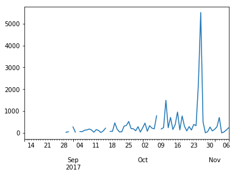

```python
from dateutil import parser
import matplotlib.pyplot as plt
df = visitAndURLs
dates = []
list(df['visit_time'])

for date in df['visit_time']:
    dates.append(str(date))
    #print type(date)
v = pd.Series(dates)
visitTimeSeries = pd.Series(1, index= v.apply(parser.parse), name = 'timeseries')
#visitTimeSeries = pd.to_datetime(visitTimeSeries.index)
visitTimeSeries
resample = visitTimeSeries.resample("D",how = "sum")
resample.plot()
plt.show()
```

### Task 2

#### Most frequently visited site: Google Docs

#### Number of Visits: 7814

```python
domainCounter.most_common(1)
```

```
[(u'docs.google.com', 7814)]
```

```python
docs = df[df['url'].str.find('docs.google.com')!=-1]
docs.shape
docs.head()
```

|  | url | visit_time | visit_duration |
| --- | --- | --- | --- |
| 178 | https://docs.google.com/a/wellesley.edu/forms/... | 2017-09-01 16:48:45.300265 | 0.000000e+00 |
| 179 | https://accounts.google.com/ServiceLogin?servi... | 2017-09-01 16:48:45.300265 | 0.000000e+00 |
| 180 | https://2fa.wellesley.edu/dag/saml2/idp/SSOSer... | 2017-09-01 16:48:45.300265 | 0.000000e+00 |
| 183 | https://2fa.wellesley.edu/dag/module.php/duose... | 2017-09-01 16:48:49.111138 | 3.067980e-13 |
| 185 | https://www.google.com/accounts/signin/continu... | 2017-09-01 16:48:50.768995 | 0.000000e+00 |

### Second Most Frequently Visited Site: FiveThirtyEight

### Number of Visits: 5682

```python
domainCounter.most_common(2)
```

```
[(u'docs.google.com', 7814), (u'fivethirtyeight.com', 5682)]
```

```python
five38 = df[df['url'].str.find('http://fivethirtyeight.com')!=-1]
five38.shape
five38.head()
```

|  | url | visit_time | visit_duration |
| --- | --- | --- | --- |
| 1760 | https://www.google.com/url?q=http://fivethirty... | 2017-09-15 04:06:11.382206 | 0.000000e+00 |
| 1761 | http://fivethirtyeight.com/features/you-cant-t... | 2017-09-15 04:06:11.382206 | 1.686669e-07 |